# Exploring whether certain behavioral parameters differ for PrEP users

This section explores whether condom use, the rate of instantaneous partnerships, and sex role differ by PrEP use, comparing men who are using PrEP or whose partners are using PrEP with men who have not used PREP in the past 12 months and who do not know that their partners are using PrEP. This analysis is to explore whether we need to specify values for these parameters for PrEP users and non-users. If so, we will use data from men not on PrEP who are similar to PrEP users (e.g. matchd on demographics and risk behaviors) to impute what the behaviors of PrEP users woudl be in the absence of PrEP. If we were to just exclude these men, we would be excluding higher risk men from the network, since PrEP use is targeted to those with higher risk behaiors.

## Rate of instantaneous partnerships

First we look at whether the rate of instantaneous partnerships overall differs by PrEP use.

Rate of instantaneous partnerships by PrEP use

| PrEP use | N | % with 0 partners | Median rate | Mean rate |
| --- | --- | --- | --- | --- |
| No recent PrEP use | 690 | 0.558 | 0.000 | 0.006 |
| PrEP use | 204 | 0.206 | 0.011 | 0.036 |

The plots below show the proportion of men in each quartile of the distribution of the rate of instantaneous partnerships (quartiles defined for the entire sample) by PrEP use.

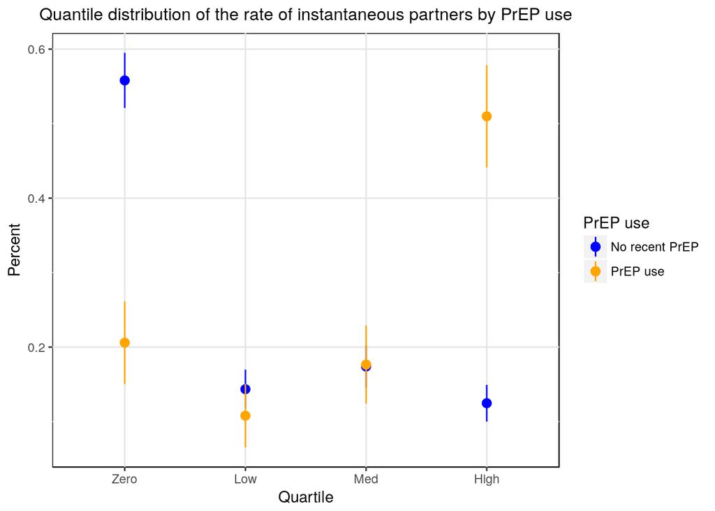

The plot below shows the proportion of men in each quartile by PrEP use and momentary degree.

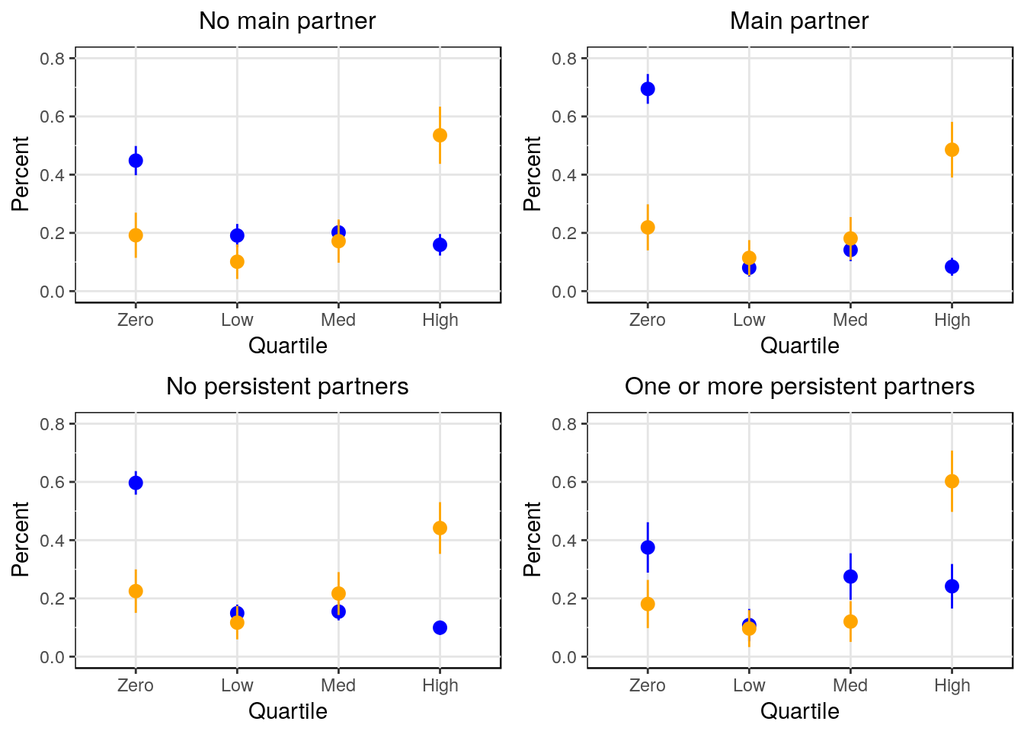

And this plot shows the proportion of men in each quartile by PrEP use and age.

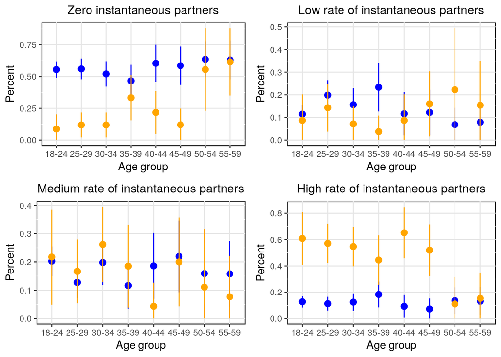

The data indicate that there are clear differences between PrEP users and non-PrEP users in terms of the rate of instantaneous partnerships, with a general pattern of greater proportion of PrEP users being in the highest quartile of the distribution and a lower proportion having zero instantaneous partners. This could be simply a reflection of the fact that PrEP use is targeted to higher risk men, but it could also be due to risk compensation. Either way, it is clear that using data only from non-PrEP users would yield a very different estimate of the rate of instantaneous partnerships than using data from the full sample.

## Condom use

The table below presents the mean probability of condom use by partner type and PrEP use (by the ego in the past 12 months or by his partner at last sex), and the proportion of men who report always and never using condoms. For instantaneous partnerships, these latter two measures convey the same information as the mean since men only reported on sex with one one-time partner. The plot shows the mean probobability with error bars indicating the 95% condfidence intervals.

Condom use by past 12 month PrEP use

| PrEP use | N | Mean | % never | % always |
| --- | --- | --- | --- | --- |
| **Main partnerships** |  |  |  |  |
| No recent PrEP use | 242 | 0.267 | 0.628 | 0.153 |
| PrEP use | 84 | 0.149 | 0.690 | 0.048 |
| **Persistent partnerships** |  |  |  |  |
| No recent PrEP use | 95 | 0.471 | 0.421 | 0.389 |
| PrEP use | 77 | 0.315 | 0.584 | 0.234 |
| **Instantaneous partnerships** |  |  |  |  |
| No recent PrEP use | 101 | 0.495 | 0.505 | 0.495 |
| PrEP use | 57 | 0.351 | 0.649 | 0.351 |

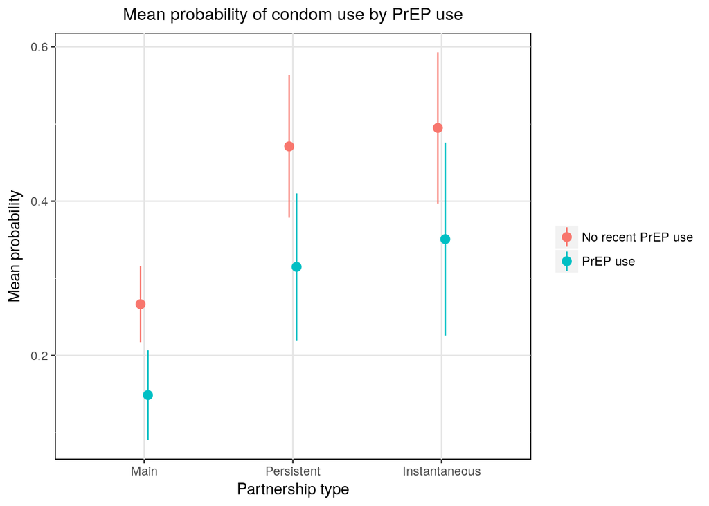

The plots below show the mean probability of condom use in each partnership type by dyad age and PrEP use.

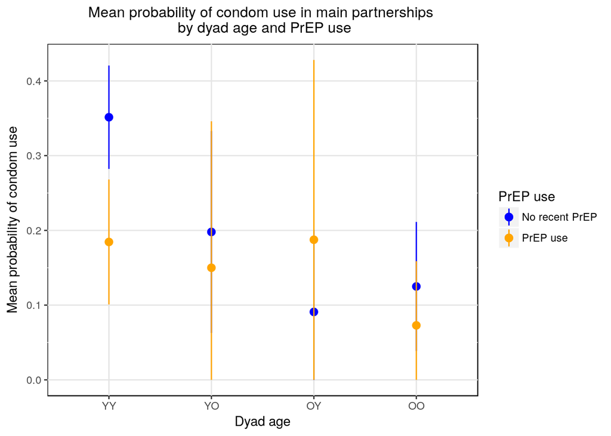

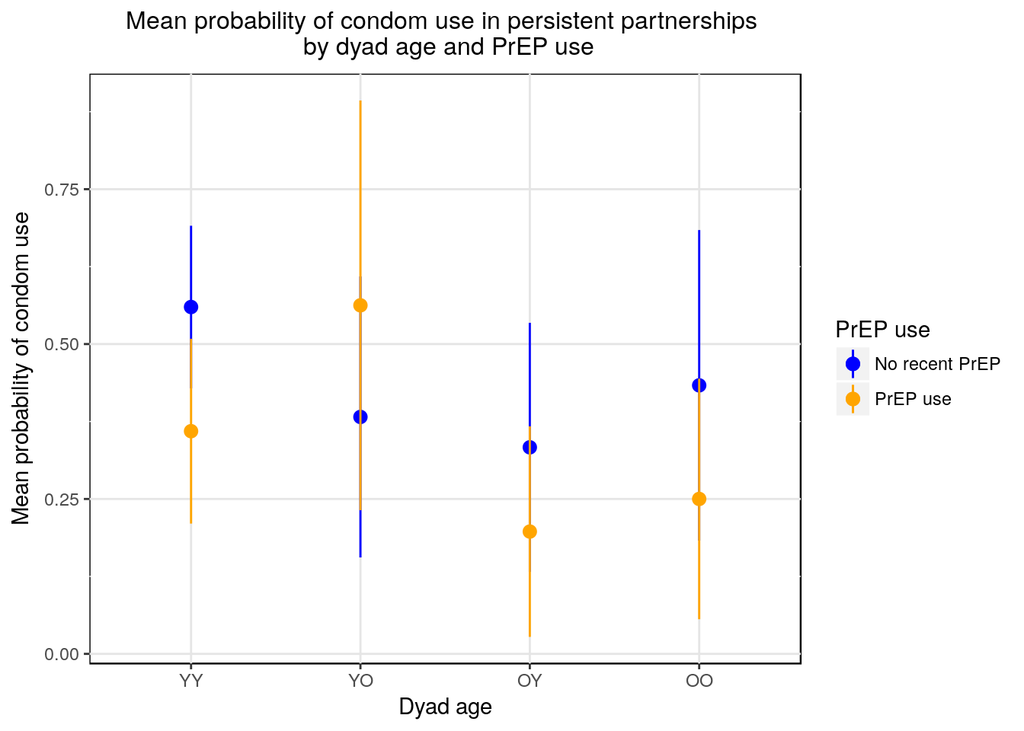

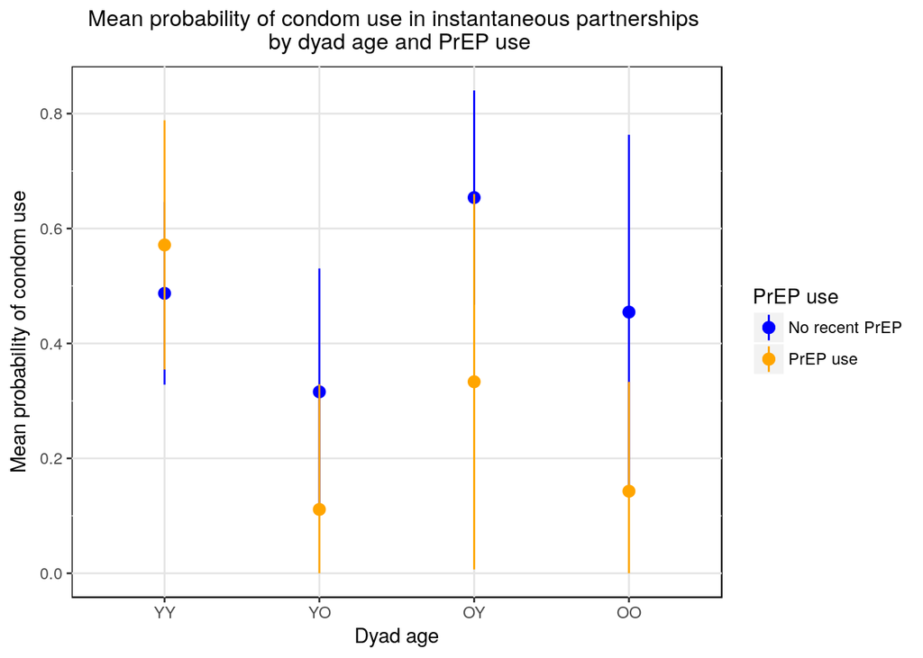

As with the rate of instantaneous partnerships, we see that condom use differs in dyads in which one or both parters used PrEP from dyads in which neither partner used PREP in the past 12 months. By age, these differences were primarily in main and persistent partnerships between two young men and in instantaneous partnerships between two older men. Again, this could be simply a reflection of the fact that PrEP use is targeted to higher risk men who may have been less likely to use condoms before starting PrEP, but it could also be due to risk compensation. Either way, using data only from non-PrEP users will produce different estimates of the rate of instantaneous partnerships than using data from the full sample, and it is unclear how much of this difference is due to risk compensation. These data suggest that imputing the likely counterfactual values for condom use in PrEP users is indicated.

## Sex role

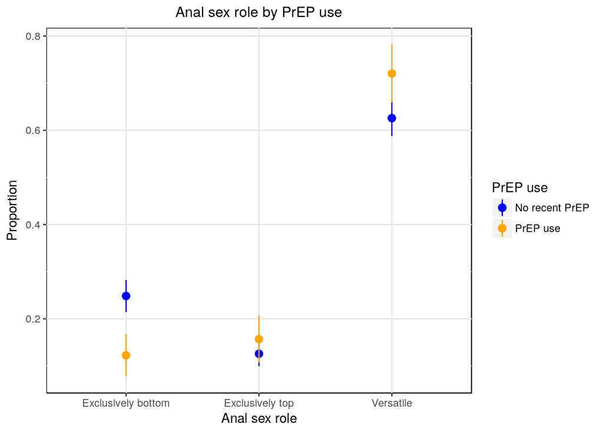

The plot for sex role also suggests some differences in anal sex role by PrEP use. Interestingly, PrEP non-users are more likely to report being exclusive bottoms than PrEP users.

# Exploring the effects of including/excluding PrEP users in estimation of behavioral parameters

Above we saw that there are differnences in the reported behaviors of PrEP users and PrEP non-users. This section examines the implications for determining the model structure by looking at whether we would reach different conclusions on how to structure the model on age, race/ethnicity and region by including or excluding data from men who have used PrEP or whose partners are using PrEP.

## Rate of instantaneous partners

This analysis looks at heterogeneity in the rate of one-time partnerships separately for men who have 0 main, those who have 1 main, those who have 0 persistent, and those who have one or more persistent partnerships. **In this analysis, we compare the findings from models including and excluding data from men who used PrEP in the past 12 months or whose partners used PrEP.**

### No main partners

We first look at how to parameterize age by plotting the ceofficients from the full model with age input as a dummy variable with 5-year age bins.

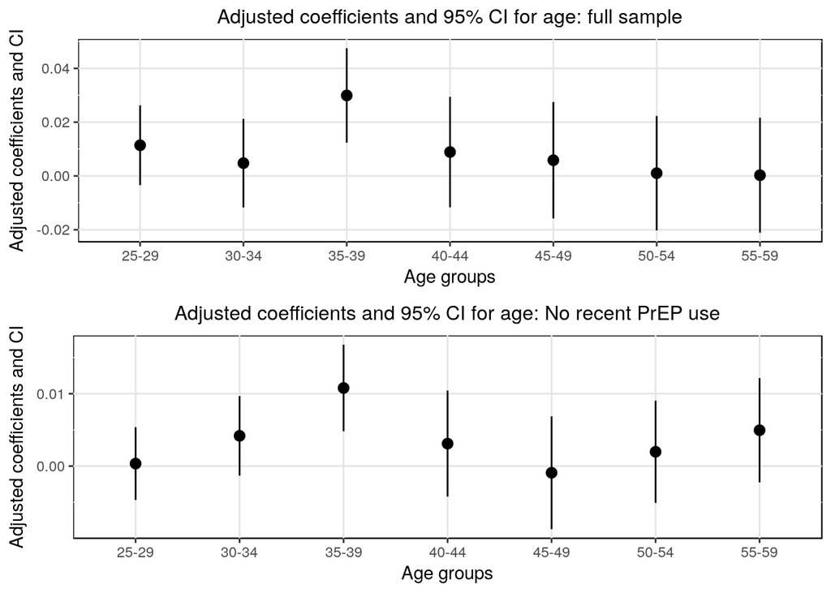

These plot both suggest that the rate of instantaneous partners is higher for men aged 35-39. To further explore the association with age, we will include age as a dummy variable, grouping together men in age groups 40-49 and 50-59.

The results of the regression analyses using data from the full sample are:

```
## [[1]]
##   Variable pvalue sig
## 1   Region 0.6042
## 2     Race 0.7896
## 3      Age 0.0246   *
##
## [[2]]
##         Variable pvalue sig
## 1 Race by region 0.6736
## 2  Age by region 0.8754
## 3    Race by age 0.2738
```

The results of the regression analyses excluding data from men who have used PrEP in the past 12 months or whose partners were using PrEP are:

```
## [[1]]
##   Variable pvalue sig
## 1   Region 0.1982
## 2     Race 0.4106
## 3      Age 0.0116   *
##
## [[2]]
##         Variable pvalue sig
## 1 Race by region 0.1455
## 2  Age by region 0.3668
## 3    Race by age 0.0000 ***
```

### Main partner

We first look at how to parameterize age by plotting the ceofficients from the full model with age input as a dummy variable with 5-year age bins.

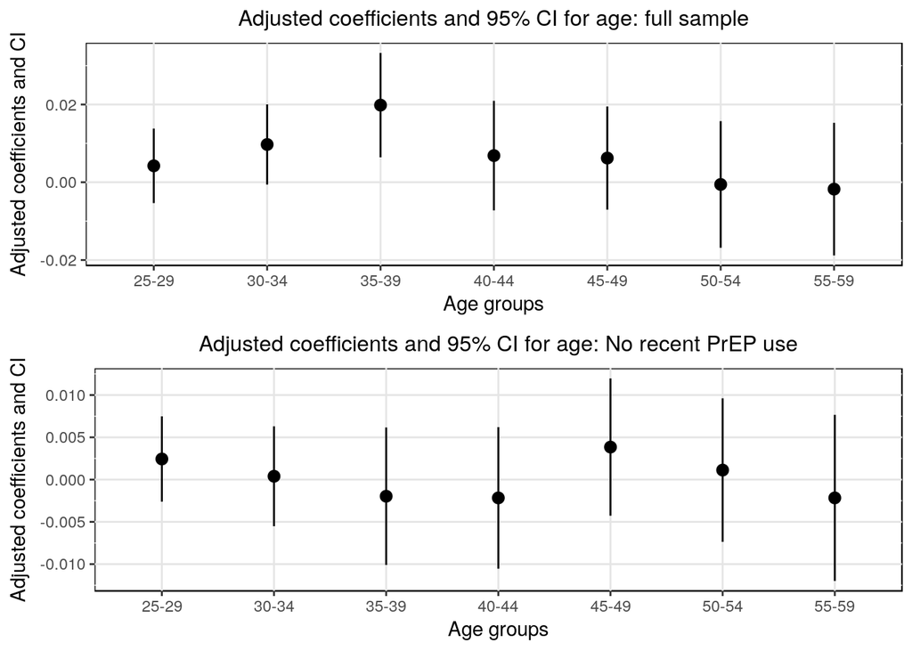

In the full sample, this plot suggests that the rate of instantaneous partners increases with age through age 39 and subsequently decreases. The plot based on data excluding current and past 12-month PrEP users does not indicate any trend by age. However to be consistent with the approach taken above, we will include age as a dummy variable in both models, grouping together men in age groups 40-49 and 50-59.

The results of the regression analyses using data from the full sample are:

```
## [[1]]
##   Variable pvalue sig
## 1   Region 0.3919
## 2     Race 0.1614
## 3      Age 0.0451   *
##
## [[2]]
##         Variable pvalue sig
## 1 Race by region 0.7025
## 2  Age by region 0.8731
## 3    Race by age 0.2770
```

The results of the regression analyses excluding men who had used PrEP in the past 12 months or whose parters were using PrEP are:

```
## [[1]]
##   Variable pvalue sig
## 1   Region 0.3385
## 2     Race 0.3096
## 3      Age 0.9013
##
## [[2]]
##         Variable pvalue sig
## 1 Race by region 0.7060
## 2  Age by region 0.9885
## 3    Race by age 0.1715
```

### No persistent partners

The plots below shoe the ceofficients for age from a model adjusting for race/ethnicity and region, with age input as a dummy variable with 5-year age bins

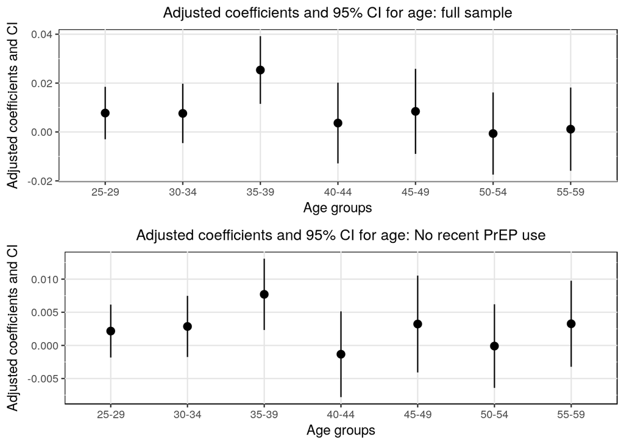

These data from both the full sample and the sample restricted to men who have not recently used PrEP and whose partners are not using PrEP suggest that the rate of instantaneous partners is higher for men aged 35-39. We will further explore the association with age, including age as a dummy variable, grouping together men in age groups 40-49 and 50-59.

The results of the regression analyses using data from the full sample are:

```
## [[1]]
##   Variable pvalue sig
## 1   Region 0.8458
## 2     Race 0.7943
## 3      Age 0.0138   *
##
## [[2]]
##         Variable pvalue sig
## 1 Race by region 0.7729
## 2  Age by region 0.8759
## 3    Race by age 0.9801
```

The results of the regression analyses excluding men who had used PrEP in the past 12 months or whose parters were using PrEP are:

```
## [[1]]
##   Variable pvalue sig
## 1   Region 0.0523
## 2     Race 0.1839
## 3      Age 0.1249
##
## [[2]]
##         Variable pvalue sig
## 1 Race by region 0.1365
## 2  Age by region 0.1835
## 3    Race by age 0.1991
```

### Any persistent partners

The plots below show the ceofficients for age from a model adjusting for race/ethnicity and region, with age input as a dummy variable with 5-year age bins

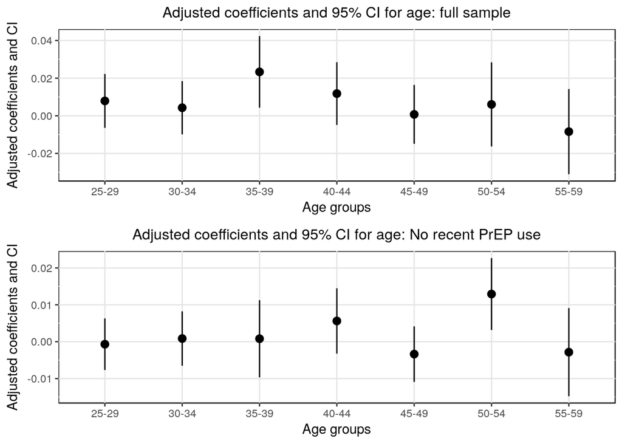

The plot of coefficients from the model using data from the full sample suggests that the rate of instantaneous partners is higher for men aged 35-39. Among men who have not used PrEP in the past 12 months and whose partners are not on PrEP, the rate of instantaneous partners appears higher for men aged 50-54. To explore these associations further, we will include age as a dummy variable in subsequent analyses, grouping together men in age groups 40-49 and 50-59.

The results of the regression analyses using data from the full sample are:

```
## [[1]]
##   Variable pvalue sig
## 1   Region 0.0870
## 2     Race 0.6340
## 3      Age 0.2077
##
## [[2]]
##         Variable pvalue sig
## 1 Race by region 0.1968
## 2  Age by region 0.6692
## 3    Race by age 0.2042
```

The results of the regression analyses excluding men who had used PrEP in the past 12 months or whose parters were using PrEP are:

```
## [[1]]
##   Variable pvalue sig
## 1   Region 0.0183   *
## 2     Race 0.0073  **
## 3      Age 0.6216
##
## [[2]]
##         Variable pvalue sig
## 1 Race by region 0.0011  **
## 2  Age by region 0.0007 ***
## 3    Race by age 0.0002 ***
```

## Condom use

Data on condom use are restricted to dyads in which both the respondent and his partner were HIV-negative or of unknown status. This analysis includes data from all such partnerships, not just those that were ongoing.

### Main partners

We first look at how to parameterize age by plotting the ceofficients from the full model with age input as a dummy variable with 5-year age bins.

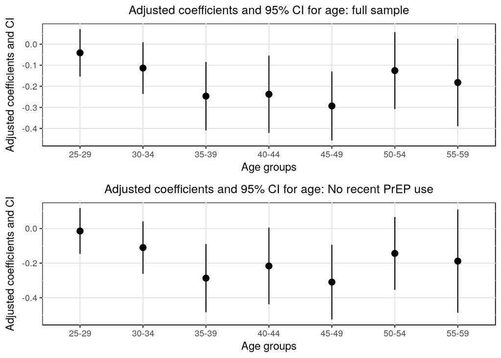

These plots suggest that condom use in main partnerships is lower for men aged 35-49 (though not quite significantly so after excluding PrEP users). The number of respondents aged 40 and higher is somewhat small, so we will group ages 40-59 in 10-year bins in subsequent analyses.

The results of the regression analyses using data from the full sample are:

```
## [[1]]
##   Variable pvalue sig
## 1   Region 0.6280
## 2     Race 0.1698
## 3      Age 0.0005 ***
##
## [[2]]
##         Variable pvalue sig
## 1 Race by region 0.0620
## 2  Age by region 0.0048  **
## 3    Race by age 0.0512
```

The results of the regression analyses excluding men who had used PrEP in the past 12 months or whose parters were using PrEP are:

```
## [[1]]
##   Variable pvalue sig
## 1   Region 0.6827
## 2     Race 0.0960
## 3      Age 0.0030  **
##
## [[2]]
##         Variable pvalue sig
## 1 Race by region 0.1163
## 2  Age by region 0.0353   *
## 3    Race by age 0.2439
```

### Persistent partners

We first look at how to parameterize age by plotting the ceofficients from the full model with age input as a dummy variable with 5-year age bins.

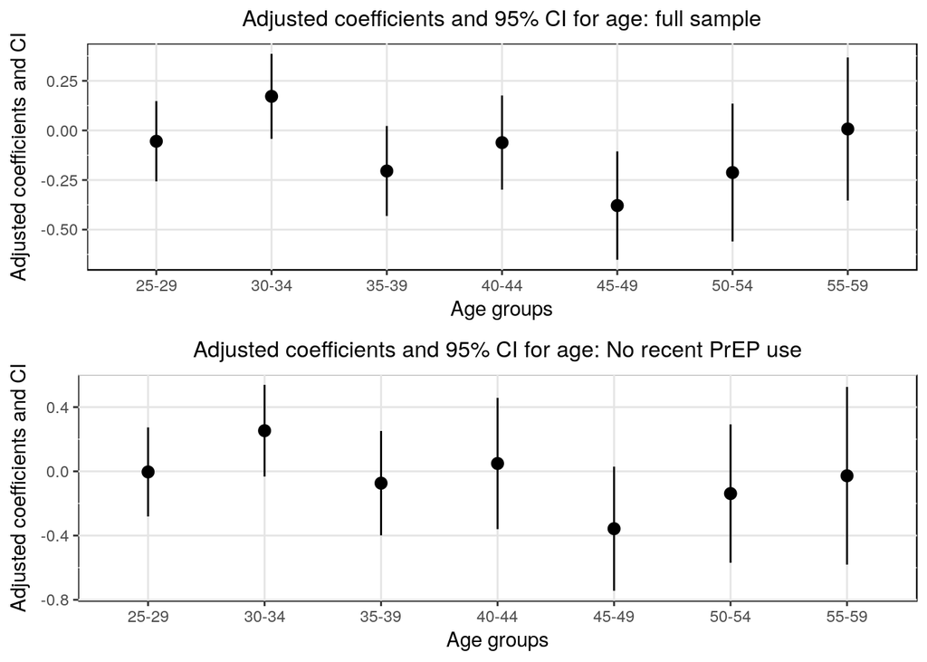

These data do not suggest a clear pattern by age for condom use with persistent partners. We will not include age in models testing associations by race/ethnicity and region.

The results of the regression analyses using data from the full sample are:

```
## [[1]]
##   Variable pvalue  sig
## 1   Region 0.3013
## 2     Race 0.0913
## 3      Age     NA <NA>
##
## [[2]]
##         Variable pvalue  sig
## 1 Race by region 0.5637
## 2  Age by region     NA <NA>
## 3    Race by age     NA <NA>
```

The results of the regression analyses excluding men who had used PrEP in the past 12 months or whose parters were using PrEP are:

```
## [[1]]
##   Variable pvalue  sig
## 1   Region 0.9016
## 2     Race 0.1525
## 3      Age     NA <NA>
##
## [[2]]
##         Variable pvalue  sig
## 1 Race by region 0.8454
## 2  Age by region     NA <NA>
## 3    Race by age     NA <NA>
```

### Instantaneous partners

We first look at how to parameterize age by plotting the ceofficients from the full model with age input as a dummy variable with 5-year age bins. When restricting to men who had not used PrEP in the past 12 months and whose partners were not taking PrEP, all 6 men aged 45-49 who reported on an instantaneous partner indicated that they used condoms, making this estimate highly unstable. We set limits to the y-axis of -4 to 4, which results in this data point being dropped due to having a very high point estimate and a wide confidence interval.

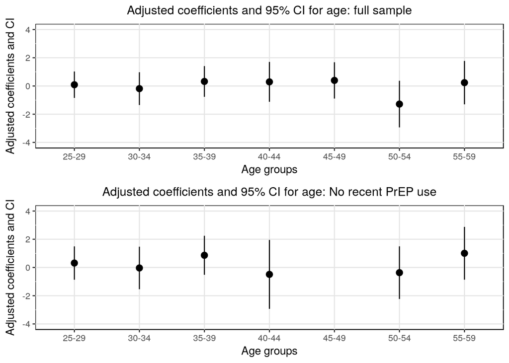

The plots of these coefficients do not suggest that there is any meaningful pattern by age for the probability of condom use with instantaneous partners. As such, age will not be included in subsequent analyses.

The results of the regression analyses using data from the full sample are:

```
## [[1]]
##   Variable pvalue  sig
## 1   Region 0.0743
## 2     Race 0.7640
## 3      Age     NA <NA>
##
## [[2]]
##         Variable pvalue  sig
## 1 Race by region 0.0129    *
## 2  Age by region     NA <NA>
## 3    Race by age     NA <NA>
```

The results of the regression analyses restricting the sample to men who had not used PrEP in the past 12 months and whose partners were not taking PrEP are:

```
## [[1]]
##   Variable pvalue  sig
## 1   Region 0.2067
## 2     Race 0.0803
## 3      Age     NA <NA>
##
## [[2]]
##         Variable pvalue  sig
## 1 Race by region 0.1325
## 2  Age by region     NA <NA>
## 3    Race by age     NA <NA>
```

## Sex role

Sex role is categorized as exclusively bottom, exclusively top, or versatile, based on men’s reported role in anal sex over the past 12 months. Responses of “mostly a bottom”, “mostly a top”, and “equally a bottom and a top” are categorized as versatile. For this analysis, dichotomous indicators was constructed to measure whether men report exclusively topping, exclusively bottoming, or a versatile sex role.

### Exclusively topping

To inform parameterization of age in models exploring heterogeneity in the proportion of men who report exclusively topping, we will plot the ceofficients from a model with age input as a dummy variable with 5-year age bins, adjusting for race/ethnicity and region.

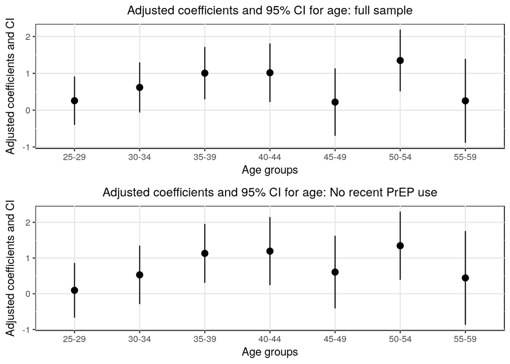

In both models, although the proportion of men reporting that they are exclusive tops seems to increase through age 44, it then fluctuates for older age groups. In subsequent models, we will represent age as a categorical variable with ages 40-59 binned in 10-year groups.

The results of the regression analyses using data from the full sample are:

```
## [[1]]
##   Variable pvalue sig
## 1   Region 0.2446
## 2     Race 0.0383   *
## 3      Age 0.0406   *
##
## [[2]]
##         Variable pvalue sig
## 1 Race by region 0.4280
## 2  Age by region 0.9384
## 3    Race by age 0.0026  **
```

The results of the regression analyses restricting the sample to men who had not used PrEP in the past 12 months and whose partners were not taking PrEP are:

```
## [[1]]
##   Variable pvalue sig
## 1   Region 0.0937
## 2     Race 0.0242   *
## 3      Age 0.0234   *
##
## [[2]]
##         Variable pvalue sig
## 1 Race by region 0.6663
## 2  Age by region 0.4999
## 3    Race by age 0.0406   *
```

### Exclusively bottoming

As above, to inform parameterization of age in models exploring heterogeneity in the proportion of men who report exclusively bottoming, we will plot the ceofficients from a model with age input as a dummy variable with 5-year age bins, adjusting for race/ethnicity and region.

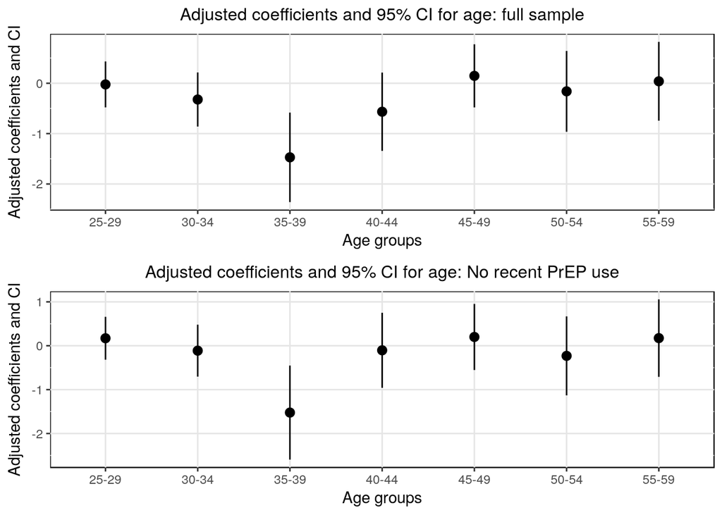

In the full sample and the subset excluding men who used PrEP in the past 12 months, the proportion of men reporting that they are exclusive bottoms seems to drop for men aged 35-39 and then increase again. To further explore this effect, in subsequent models, we will represent age as a categorical variable with ages 40-59 binned in 10-year groups.

The results of the regression analyses using data from the full sample are:

```
## [[1]]
##   Variable pvalue sig
## 1   Region 0.8890
## 2     Race 0.0049  **
## 3      Age 0.0073  **
##
## [[2]]
##         Variable pvalue sig
## 1 Race by region 0.6190
## 2  Age by region 0.1008
## 3    Race by age 0.0151   *
```

The results of the regression analyses restricting the sample to men who had not used PrEP in the past 12 months and whose partners were not taking PrEP are:

```
## [[1]]
##   Variable pvalue sig
## 1   Region 0.9056
## 2     Race 0.0051  **
## 3      Age 0.0183   *
##
## [[2]]
##         Variable pvalue sig
## 1 Race by region 0.6076
## 2  Age by region 0.0285   *
## 3    Race by age 0.1435
```

### Versatile

To inform parameterization of age in models exploring heterogeneity in the proportion of men who report being versatile in their anal sex role, we will plot the ceofficients from a model with age input as a dummy variable with 5-year age bins, adjusting for race/ethnicity and region.

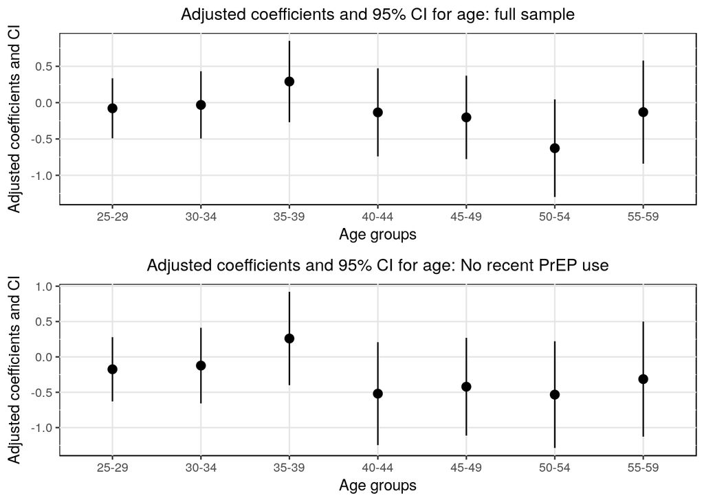

These data do not suggest any clear trend by age. However, because sex role will be represented in the model using one 3-level variable for exclusively top, exclusively bottom, or versatile, we will include age in the models below as a categorical variable to be consistent with the approach taken for the indicators of exclusively topping and exclusively bottoming.

The results of the regression analyses using data from the full sample are:

```
## [[1]]
##   Variable pvalue sig
## 1   Region 0.3840
## 2     Race 0.0145   *
## 3      Age 0.4563
##
## [[2]]
##         Variable pvalue sig
## 1 Race by region 0.1857
## 2  Age by region 0.1885
## 3    Race by age 0.0040  **
```

The results of the regression analyses restricting the sample to men who had not used PrEP in the past 12 months and whose partners were not taking PrEP are:

```
## [[1]]
##   Variable pvalue sig
## 1   Region 0.4320
## 2     Race 0.0028  **
## 3      Age 0.3168
##
## [[2]]
##         Variable pvalue sig
## 1 Race by region 0.2136
## 2  Age by region 0.2526
## 3    Race by age 0.1524
```